# mbruner3_3

Mark Bruner

10/4/2020

# Libraries needed for this assignment.

# Imported dataset.

| CRS_DEP_TIME | CARRIER | DEP_TIME | DEST | DISTANCE | FL_DATE | FL_NUM | ORIGIN | Weather | DAY_WEEK | DAY_OF_MONTH | TAIL_NUM | Flight Status |
| --- | --- | --- | --- | --- | --- | --- | --- | --- | --- | --- | --- | --- |
| 1455 | OH | 1455 | JFK | 184 | 2004-01-01 | 5935 | BWI | 0 | 4 | 1 | N940CA | ontime |
| 1640 | DH | 1640 | JFK | 213 | 2004-01-01 | 6155 | DCA | 0 | 4 | 1 | N405FJ | ontime |
| 1245 | DH | 1245 | LGA | 229 | 2004-01-01 | 7208 | IAD | 0 | 4 | 1 | N695BR | ontime |
| 1715 | DH | 1709 | LGA | 229 | 2004-01-01 | 7215 | IAD | 0 | 4 | 1 | N662BR | ontime |
| 1039 | DH | 1035 | LGA | 229 | 2004-01-01 | 7792 | IAD | 0 | 4 | 1 | N698BR | ontime |
| 840 | DH | 839 | JFK | 228 | 2004-01-01 | 7800 | IAD | 0 | 4 | 1 | N687BR | ontime |

# Getting to know data.

```r
summary(flight_delays)
```

```
##   CRS_DEP_TIME     CARRIER       DEP_TIME     DEST         DISTANCE
##  Min.   : 600   DH     :551   Min.   :  10   JFK: 386   Min.   :169.0
##  1st Qu.:1000   RU     :408   1st Qu.:1004   LGA:1150   1st Qu.:213.0
##  Median :1455   US     :404   Median :1450   EWR: 665   Median :214.0
##  Mean   :1372   DL     :388   Mean   :1369              Mean   :211.9
##  3rd Qu.:1710   MQ     :295   3rd Qu.:1709              3rd Qu.:214.0
##  Max.   :2130   CO     : 94   Max.   :2330              Max.   :229.0
##                 (Other): 61
##     FL_DATE               FL_NUM     ORIGIN     Weather  DAY_WEEK
##  Min.   :2004-01-01   7800   :  31   BWI: 145   0:2169   4:372
##  1st Qu.:2004-01-08   7806   :  31   DCA:1370   1:  32   5:391
##  Median :2004-01-16   7812   :  31   IAD: 686            6:250
##  Mean   :2004-01-16   7814   :  31                       7:253
##  3rd Qu.:2004-01-23   746    :  31                       1:308
##  Max.   :2004-01-31   1768   :  31                       2:307
##                       (Other):2015                       3:320
##   DAY_OF_MONTH     TAIL_NUM    Flight Status
##  22     :  86   N225DL :  65   ontime :1773
##  6      :  85   N242DL :  56   delayed: 428
##  8      :  85   N223DZ :  50
##  13     :  85   N221DL :  45
##  20     :  85   N241DL :  36
##  21     :  85   N722UW :  36
##  (Other):1690   (Other):1913
```

**The five main carriers for the flights are DH, RU, US, DL, and MQ. Over half of the flights are to LGA (La Guardia, NY). The mean and median a fairly close together for the distance variable which means that the distribution is symmetrical. Most of the flights originated out of DCA (Washington DC). The weather only impacted 32/2201 flights and caused delays from January 25 to January 27th mostly. More flights occurred on days 4 and 5. Lastly, about 19% of all flights were delayed in January.**

# Checked for missing values and created dummy variables.

```r
colMeans(is.na(flight_delays)) # no missing data.
```

```
##  CRS_DEP_TIME       CARRIER      DEP_TIME          DEST      DISTANCE
##             0             0             0             0             0
##       FL_DATE        FL_NUM        ORIGIN       Weather      DAY_WEEK
##             0             0             0             0             0
##  DAY_OF_MONTH      TAIL_NUM Flight Status
##             0             0             0
```

```r
flight_delays <- dummy_cols(flight_delays, select_columns = "Flight Status", remove_selected_columns = TRUE)

flight_delays <- flight_delays %>%
  rename("On Time" = "Flight Status_ontime")

flight_delays <- flight_delays %>%
  rename("Delayed" = "Flight Status_delayed")

flight_delays$`On Time` <- as.factor(flight_delays$`On Time`)
flight_delays$Delayed <- as.factor(flight_delays$Delayed)
```

**Since all variables have column means of 0, that implies that there are no missing values in this dataset.**

# Created “bins” for CRS_DEP_TIME (Scheduled Departure Time).

```r
library(OneR)
flight_delays_time <- as.data.frame(bin(flight_delays$CRS_DEP_TIME, nbins = 18, labels = c(1:18)))

flight_delays <- cbind(flight_delays_time, flight_delays)

flight_delays <- flight_delays %>% rename("CRS_DEP_TIME GROUP NO" = "bin(flight_delays$CRS_DEP_TIME, nbins = 18, labels = c(1:18))")

flight_delays %>%
  group_by(`CRS_DEP_TIME GROUP NO`) %>%
  summarise(CRS_DEP_TIME = length(`CRS_DEP_TIME GROUP NO`))
```

| CRS_DEP_TIME GROUP NO | CRS_DEP_TIME |
| --- | --- |
| 1 | 126 |
| 2 | 135 |
| 3 | 162 |
| 4 | 108 |
| 5 | 23 |
| 6 | 125 |
| 7 | 42 |
| 8 | 120 |
| 9 | 157 |
| 10 | 98 |

[output cut: 8 more lines]

```r
flight_delays <- flight_delays[, -2]
head(flight_delays)
```

|  | CRS_DEP_TIME GROUP NO | CARRIER | DEP_TIME | DEST | DISTANCE | FL_DATE | FL_NUM | ORIGIN | Weather | DAY_WEEK | DAY_OF_MONTH | TAIL_NUM | On Time | Delayed |
| --- | --- | --- | --- | --- | --- | --- | --- | --- | --- | --- | --- | --- | --- | --- |
| 1 | 11 | OH | 1455 | JFK | 184 | 2004-01-01 | 5935 | BWI | 0 | 4 | 1 | N940CA | 1 | 0 |
| 2 | 13 | DH | 1640 | JFK | 213 | 2004-01-01 | 6155 | DCA | 0 | 4 | 1 | N405FJ | 1 | 0 |
| 3 | 8 | DH | 1245 | LGA | 229 | 2004-01-01 | 7208 | IAD | 0 | 4 | 1 | N695BR | 1 | 0 |
| 4 | 14 | DH | 1709 | LGA | 229 | 2004-01-01 | 7215 | IAD | 0 | 4 | 1 | N662BR | 1 | 0 |
| 5 | 6 | DH | 1035 | LGA | 229 | 2004-01-01 | 7792 | IAD | 0 | 4 | 1 | N698BR | 1 | 0 |
| 6 | 3 | DH | 839 | JFK | 228 | 2004-01-01 | 7800 | IAD | 0 | 4 | 1 | N687BR | 1 | 0 |

# Separated dataset into only predictors and then partitioned it into training and vaildation sets.

```r
flight_delays_predictors <- flight_delays[, c(1, 2, 4, 8, 10, 14)] # created df with predictors.

set.seed(15)
index_train <- createDataPartition(flight_delays_predictors$DAY_WEEK, p = .6, list = FALSE)
flight_train <- flight_delays_predictors[index_train, ]
flight_valid <- flight_delays_predictors[-index_train, ]
head(flight_train)
```

|  | CRS_DEP_TIME GROUP NO | CARRIER | DEST | ORIGIN | DAY_WEEK | Delayed |
| --- | --- | --- | --- | --- | --- | --- |
| 1 | 11 | OH | JFK | BWI | 4 | 0 |
| 2 | 13 | DH | JFK | DCA | 4 | 0 |
| 6 | 3 | DH | JFK | IAD | 4 | 0 |
| 7 | 8 | DH | JFK | IAD | 4 | 0 |
| 8 | 13 | DH | JFK | IAD | 4 | 0 |
| 9 | 14 | DH | JFK | IAD | 4 | 0 |

# Naive Bayes Model with training data.

```r
naive_model <- naive_bayes(flight_train[, 1:5], flight_train[, 6], laplace = 1)
```

# Predicting delayed/on-time flights on validation dataset.

```r
predicted_flight_labels <- predict(naive_model, flight_valid, type = "class")
```

# Destination and Origin Proportion and Count Tables

```r
table(predicted_flight_labels, flight_valid$Delayed, dnn = c("Prediction", "Actual"))
```

```
##           Actual
## Prediction   0   1
##          0 684 148
##          1  25  21
```

```r
dest_prop <- as.data.frame(naive_model$tables$DEST)
dest_count_delay <- as.data.frame(dest_prop[1:3, 3]*832)
dest_count_delay <- rename(dest_count_delay, Count = `dest_prop[1:3, 3] * 832`)
dest_count_ontime <- as.data.frame(dest_prop[4:6, 3]*46)
dest_count_ontime <- rename(dest_count_ontime, Count = `dest_prop[4:6, 3] * 46`)

dest_count <- rbind(dest_count_delay, dest_count_ontime)
dest_count_prop <- cbind(dest_prop, dest_count)

origin_prop <- as.data.frame(naive_model$tables$ORIGIN)
origin_count_delay <- as.data.frame(origin_prop[1:3, 3]*832)
origin_count_delay <- rename(origin_count_delay, Count = `origin_prop[1:3, 3] * 832`)
origin_count_ontime <- as.data.frame(origin_prop[4:6, 3]*46)
origin_count_ontime <- rename(origin_count_ontime, Count = `origin_prop[4:6, 3] * 46`)

origin_count <- rbind(origin_count_delay, origin_count_ontime)
origin_count_prop <- cbind(origin_prop, origin_count)

dest_count_prop <- rename(dest_count_prop, "Ontime/Delayed" = Var2, Proportion = "Freq")
dest_count_prop
```

| DEST | Ontime/Delayed | Proportion | Count |
| --- | --- | --- | --- |
| JFK | 0 | 0.1733833 | 144.254920 |
| LGA | 0 | 0.5501406 | 457.716963 |
| EWR | 0 | 0.2764761 | 230.028116 |
| JFK | 1 | 0.1755725 | 8.076336 |
| LGA | 1 | 0.4351145 | 20.015267 |
| EWR | 1 | 0.3893130 | 17.908397 |

```r
origin_count_prop <- rename(origin_count_prop, "Ontime/Delayed" = Var2, Proportion = "Freq")
origin_count_prop
```

| ORIGIN | Ontime/Delayed | Proportion | Count |
| --- | --- | --- | --- |
| BWI | 0 | 0.05810684 | 48.344892 |
| DCA | 0 | 0.64292409 | 534.912840 |
| IAD | 0 | 0.29896907 | 248.742268 |
| BWI | 1 | 0.09541985 | 4.389313 |
| DCA | 1 | 0.50763359 | 23.351145 |
| IAD | 1 | 0.39694656 | 18.259542 |

**This models predicts that JFK will have 8 delays, LGA will have 20 delays, and that EWR will have 18 delays. Also, that BWI will have 4 delays, DCA will have 23 delays, and that IAD will have 18 delays.**

```r
library(gmodels)
confusionMatrix(flight_valid$Delayed, predicted_flight_labels, dnn = c("Actual", "Prediction"))
```

```
## Confusion Matrix and Statistics
##
##       Prediction
## Actual   0   1
##      0 684  25
##      1 148  21
##
##                Accuracy : 0.803
##                  95% CI : (0.7751, 0.8288)
##     No Information Rate : 0.9476
##     P-Value [Acc > NIR] : 1
##
##                   Kappa : 0.1231
##
##  Mcnemar's Test P-Value : <2e-16
##
##             Sensitivity : 0.8221
##             Specificity : 0.4565
##          Pos Pred Value : 0.9647
##          Neg Pred Value : 0.1243
##              Prevalence : 0.9476
##          Detection Rate : 0.7790
##    Detection Prevalence : 0.8075
##       Balanced Accuracy : 0.6393
##
##        'Positive' Class : 0
##
```

```r
library(pROC)
predicted_flight_labels <- predict(naive_model, flight_valid, type = "prob")
roc(flight_valid$Delayed, predicted_flight_labels[, 2])
```

```
##
## Call:
## roc.default(response = flight_valid$Delayed, predictor = predicted_flight_labels[,     2])
##
## Data: predicted_flight_labels[, 2] in 709 controls (flight_valid$Delayed 0) < 169 cases (flight_valid$Delayed 1).
## Area under the curve: 0.646
```

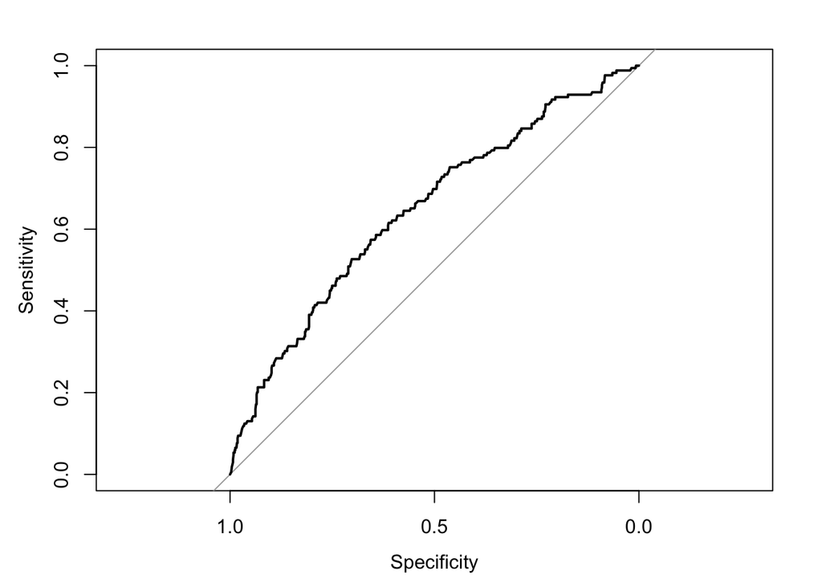

```r
plot.roc(flight_valid$Delayed, predicted_flight_labels[, 2])
```

**The area under this curve is 64.6% which tells us that this model can be further improved since we want area to be reasonably close to 100%.**